# TEMA 1: INTRODUCCIÓN A LA ECONOMETRÍA

- Show All Code
- Hide All Code
- View Source

Aplicación 1.2 (Datos de series temporales): Consumo privado en Estados Unidos

Author

Julián Ramajo

## Introducción

En esta aplicación se estimará una función de consumo agregada (consumidor representativo) de tipo Keynesiano con datos de series temporales para Estados Unidos durante el período 1959-2015 ( *t* = 1, 2,…, 57):

$$C_{t} = f(Y_{t}) + e_{t}$$

donde *C* representa la consumo privado, e *Y* es la renta disponible (después de impuestos).

## Configuración

Inicialización de Python (`recitulate`) y Julia (`JuliaCall`) para poder ejecutar simulténeamente la aplicación en los tres lenguajes.

```r
library(reticulate)
use_python("/usr/local/bin/python3.10")
```

```r
library(JuliaCall)
julia_setup(JULIA_HOME = "/Applications/Julia-1.8.app/Contents/Resources/julia/bin")
```

```
Julia version 1.8.1 at location /Applications/Julia-1.8.app/Contents/Resources/julia/bin will be used.
```

```
Loading setup script for JuliaCall...
```

```
Finish loading setup script for JuliaCall.
```

## Lectura de librerías (*packages*)

Librerías necesarias para la ejecución de la aplicación.

**R**

```r
library(tidyverse)
library(GGally)
library(skimr)
library(coefplot)
library(report)
```

**Python**

```python
import numpy as np
import pandas as pd
import statsmodels.api as sm
import statsmodels.formula.api as smf
import matplotlib.pyplot as plt
```

**Julia**

```julia
using DataFrames, CSV, GLM, Econometrics, RegressionTables, TimeSeries
```

## Datos

Lectura y descripción de los datos.

**R**

Usando el `tidyverse` (https://www.tidyverse.org/).

```r
# Lectura de datos
CONS_USA <- read_delim("CONS_USA_ts.csv", delim = ";", escape_double = FALSE, trim_ws = TRUE)
head(CONS_USA)
```

```
# A tibble: 6 × 3
  date           C     Y
  <date>     <dbl> <dbl>
1 1959-01-01 1840. 2092.
2 1960-01-01 1891  2147
3 1961-01-01 1930. 2223.
4 1962-01-01 2025. 2329
5 1963-01-01 2109. 2417.
6 1964-01-01 2234. 2588.
```

```r
tail(CONS_USA)
```

```
# A tibble: 6 × 3
  date            C      Y
  <date>      <dbl>  <dbl>
1 2010-01-01 10036. 11055.
2 2011-01-01 10264. 11331.
3 2012-01-01 10413. 11688.
4 2013-01-01 10565. 11528.
5 2014-01-01 10869. 11931
6 2015-01-01 11215. 12343.
```

```r
#
# Asignación del formato de series temporales
# (https://cran.r-project.org/web/views/TimeSeries.html)
# Aquí se usará la clase básica "ts", válida para series temporales
# regulares (espaciadas de forma homogénea en el tiempo).
# Pueden usarse otras clases más generales, siendo las más usadas:
# "zoo": https://cran.r-project.org/web/packages/zoo/index.html
# "xts": https://github.com/joshuaulrich/xts
# "tsibble" (Ver Anexo 1 para una sencilla demostración)
#
ts_CONS_USA <- ts(CONS_USA, start=c(1959), end = c(2015))
# Análisis exploratorio (EDA)
# Estadística descriptiva
summary(ts_CONS_USA)
```

```
      date             C               Y
 Min.   :-4018   Min.   : 1840   Min.   : 2092
 1st Qu.: 1096   1st Qu.: 3330   1st Qu.: 3924
 Median : 6209   Median : 5184   Median : 5811
 Mean   : 6209   Mean   : 5747   Mean   : 6418
 3rd Qu.:11323   3rd Qu.: 8383   3rd Qu.: 9149
 Max.   :16436   Max.   :11215   Max.   :12343
```

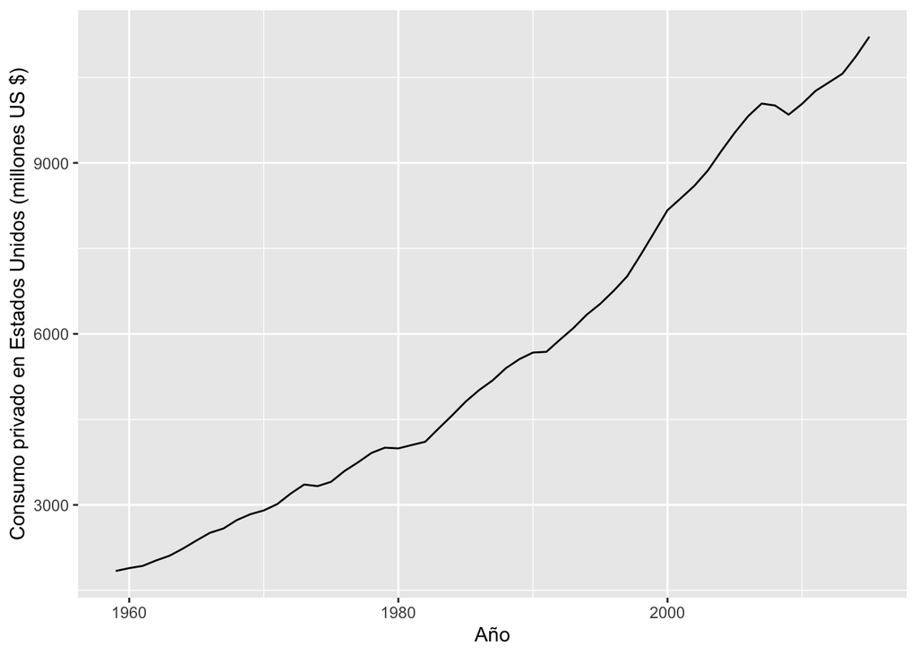

```r
# Gráficas
#ts.plot(ts_CONS_USA[,"C"])
g1 <- ggplot(data = CONS_USA, aes(x = date)) +
  geom_line(aes(y = C), size = 0.5) +
  labs(y = "Consumo privado en Estados Unidos (millones US $)", x = "Año")
g1
```

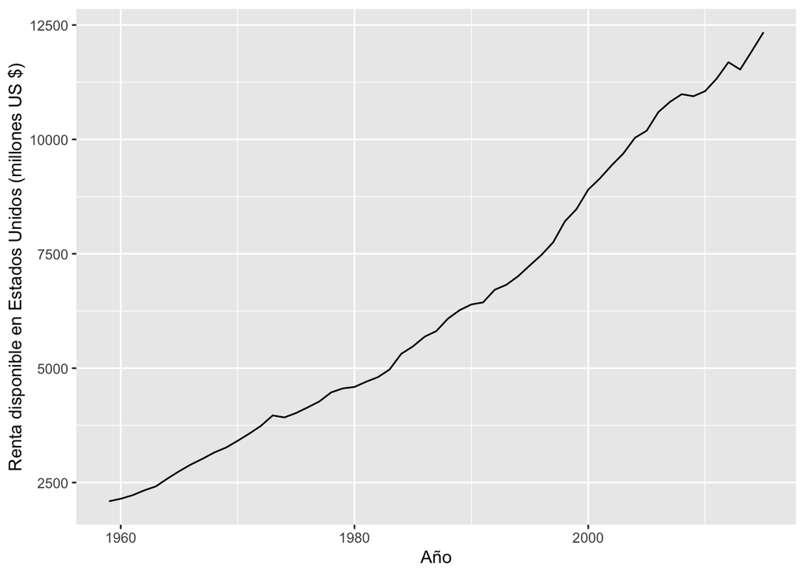

```r
#ts.plot(ts_CONS_USA[,"Y"])
g2 <- ggplot(data = CONS_USA, aes(x = date)) +
  geom_line(aes(y = Y), size = 0.5) +
  labs(y = "Renta disponible en Estados Unidos (millones US $)", x = "Año")
g2
```

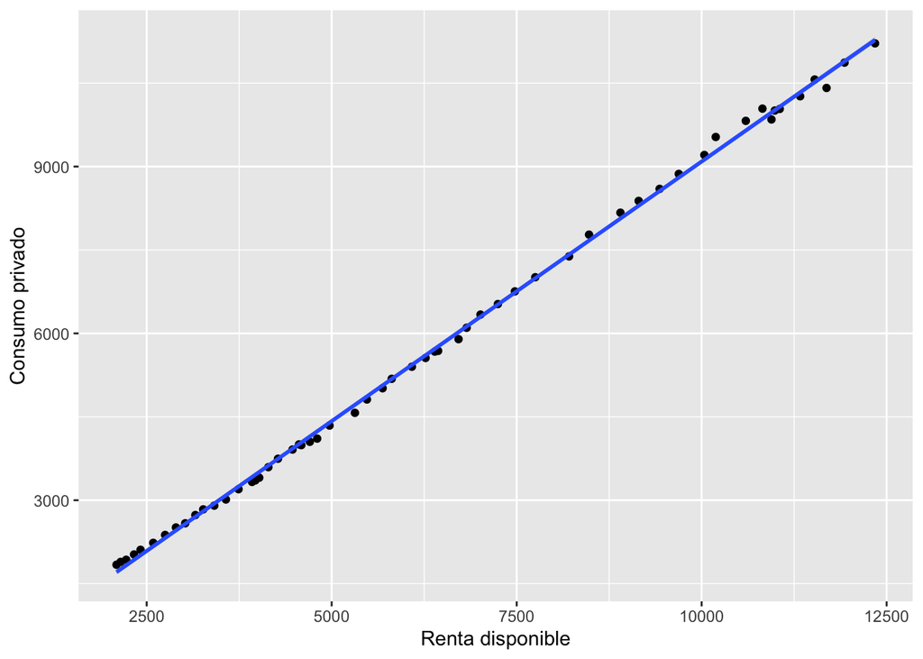

```r
#CONS_USA %>% ggplot(aes(x = Y, y = C)) + geom_point() + ylab("C") + xlab("Y")
g3 <- ggplot(CONS_USA, aes(x = Y, y = C)) +
               geom_point() +
               stat_smooth(method = lm) +
               labs(x = "Renta disponible",y = "Consumo privado")
g3
```

**Python**

Usando `pandas` (https://pandas.pydata.org/).

```python
# Lectura de datos
CONS_USA = pd.read_csv("CONS_USA_ts.csv", delimiter=';')
#
# Asignación del formato temporal
# (https://pandas.pydata.org/docs/user_guide/timeseries.html#)
# Un análisis detallado puede encontrarse en la siguiente página web:
# https://jakevdp.github.io/PythonDataScienceHandbook/03.11-working-with-time-series.html
#
ts_CONS_USA = pd.read_csv("CONS_USA_ts.csv", delimiter=';', index_col=0)
ts_CONS_USA.head()
```

```
                 C       Y
date
1959-01-01  1840.5  2092.1
1960-01-01  1891.0  2147.0
1961-01-01  1929.9  2222.7
1962-01-01  2025.4  2329.0
1963-01-01  2108.8  2416.6
```

```python
ts_CONS_USA.tail()
# Estadística descriptiva
```

```
                  C        Y
date
2011-01-01  10263.5  11331.3
2012-01-01  10413.2  11687.8
2013-01-01  10565.4  11527.6
2014-01-01  10868.9  11931.0
2015-01-01  11214.7  12343.2
```

```python
ts_CONS_USA.describe()
# Gráficas
```

```
                  C             Y
count     57.000000     57.000000
mean    5746.605263   6418.347368
std     2924.557484   3131.033192
min     1840.500000   2092.100000
25%     3329.500000   3923.900000
50%     5183.600000   5811.100000
75%     8382.600000   9148.800000
max    11214.700000  12343.200000
```

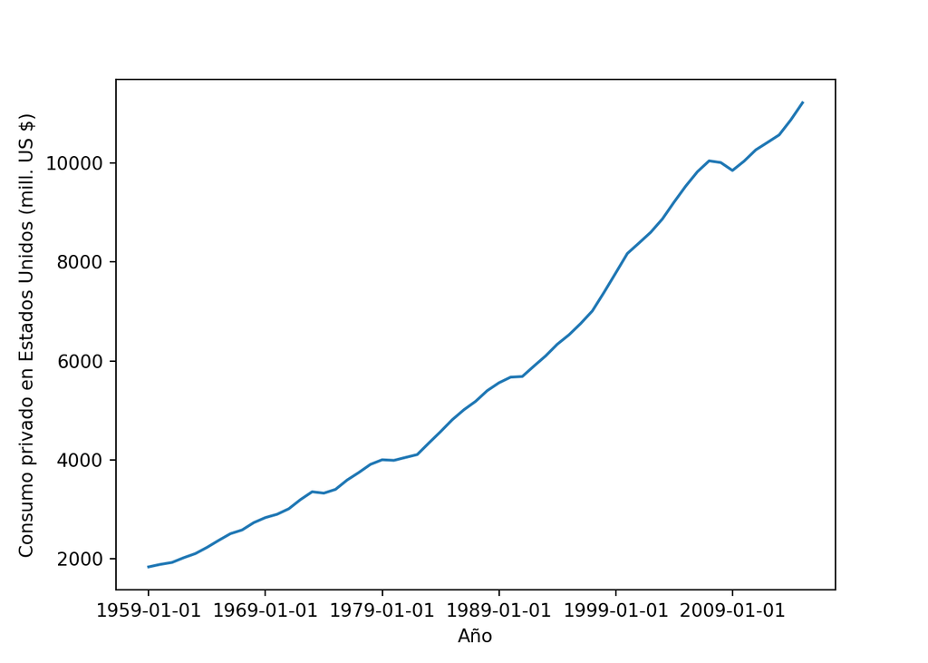

```python
ts_CONS_USA["C"].plot()
#plt.plot(ts_CONS_USA["C"])
plt.xlabel("Año")
plt.ylabel("Consumo privado en Estados Unidos (mill. US $)")
plt.show()
```

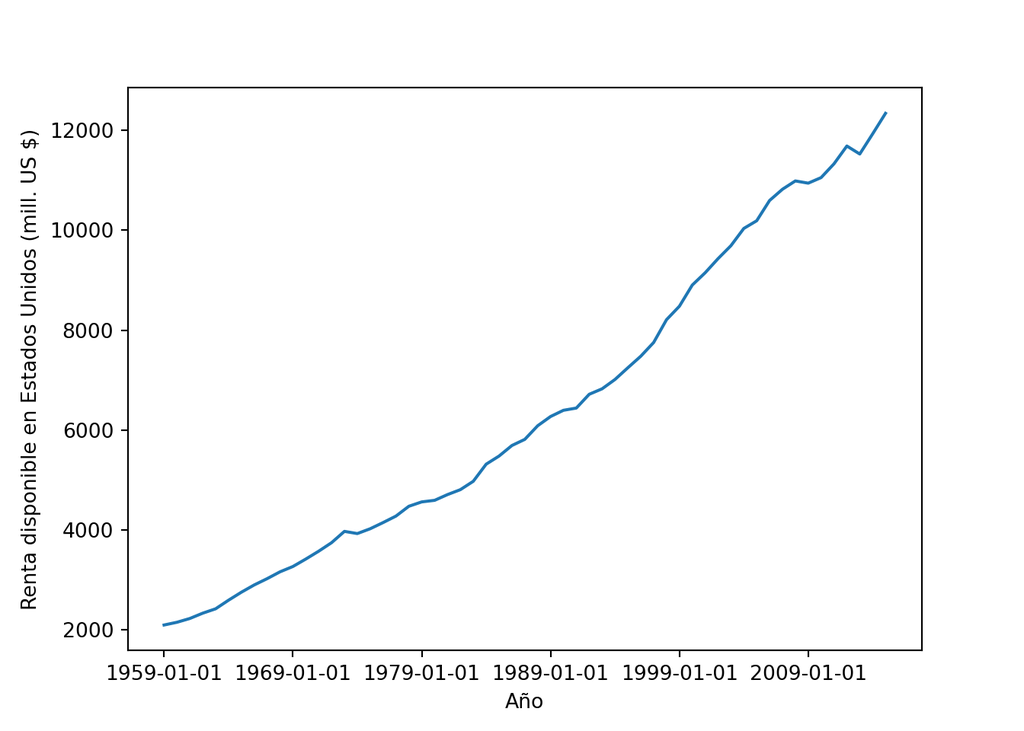

```python
ts_CONS_USA["Y"].plot()
#plt.plot(ts_CONS_USA["Y"])
plt.xlabel("Año")
plt.ylabel("Renta disponible en Estados Unidos (mill. US $)")
plt.show()
```

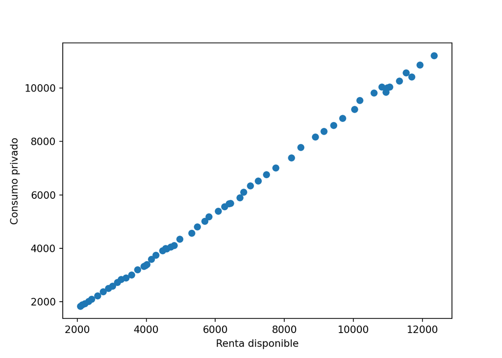

```python
plt.scatter(ts_CONS_USA["Y"], ts_CONS_USA["C"])
plt.xlabel("Renta disponible")
plt.ylabel("Consumo privado")
plt.show()
```

**Julia**

Usando `DataFrames` (https://dataframes.juliadata.org/stable/).

```julia
# Lectura y descripción de la base de datos
CONS_USA = CSV.read("CONS_USA_ts.csv", DataFrame);
show(first(CONS_USA,6))
```

```
6×3 DataFrame
 Row │ date        C        Y
     │ Date        Float64  Float64
─────┼──────────────────────────────
   1 │ 1959-01-01   1840.5   2092.1
   2 │ 1960-01-01   1891.0   2147.0
   3 │ 1961-01-01   1929.9   2222.7
   4 │ 1962-01-01   2025.4   2329.0
   5 │ 1963-01-01   2108.8   2416.6
   6 │ 1964-01-01   2234.4   2588.2
```

```julia
show(last(CONS_USA,6))
```

```
6×3 DataFrame
 Row │ date        C        Y
     │ Date        Float64  Float64
─────┼──────────────────────────────
   1 │ 2010-01-01  10036.3  11055.2
   2 │ 2011-01-01  10263.5  11331.3
   3 │ 2012-01-01  10413.2  11687.8
   4 │ 2013-01-01  10565.4  11527.6
   5 │ 2014-01-01  10868.9  11931.0
   6 │ 2015-01-01  11214.7  12343.2
```

```julia
#
# Asignación del formato temporal
# Librería básica para el análisis de series temporales:
# TimeSeries (https://juliapackages.com/p/timeseries)
# que tiene el formato TimeArray.
# También puede usarse la librería Temporal
# (https://juliapackages.com/p/temporal)
# con formato TS.
# La información más relevante sobre el análisis de series temporales
# con Julia se encuentra disponible en la página web:
# https://discourse.julialang.org/t/time-series-in-julia-working-list/62539
#
ts_CONS_USA = TimeArray(CONS_USA, timestamp = :date)
```

```
57×2 TimeArray{Float64, 2, Date, Matrix{Float64}} 1959-01-01 to 2015-01-01
│            │ C       │ Y       │
├────────────┼─────────┼─────────┤
│ 1959-01-01 │ 1840.5  │ 2092.1  │
│ 1960-01-01 │ 1891.0  │ 2147.0  │
│ 1961-01-01 │ 1929.9  │ 2222.7  │
│ 1962-01-01 │ 2025.4  │ 2329.0  │
│ 1963-01-01 │ 2108.8  │ 2416.6  │
│ 1964-01-01 │ 2234.4  │ 2588.2  │
│ 1965-01-01 │ 2376.0  │ 2748.9  │
│ 1966-01-01 │ 2510.6  │ 2895.0  │
│ 1967-01-01 │ 2585.6  │ 3020.6  │
   ⋮
│ 2008-01-01 │ 10007.2 │ 10988.3 │
│ 2009-01-01 │ 9847.0  │ 10943.7 │
│ 2010-01-01 │ 10036.3 │ 11055.2 │
│ 2011-01-01 │ 10263.5 │ 11331.3 │
│ 2012-01-01 │ 10413.2 │ 11687.8 │
│ 2013-01-01 │ 10565.4 │ 11527.6 │
│ 2014-01-01 │ 10868.9 │ 11931.0 │
│ 2015-01-01 │ 11214.7 │ 12343.2 │
```

```julia
# Estadística descriptiva (describe no funciona con el formato TimeArray)
show(describe(CONS_USA))
```

```
3×7 DataFrame
 Row │ variable  mean     min         median      max         nmissing  eltype ⋯
     │ Symbol    Union…   Any         Any         Any         Int64     DataTy ⋯
─────┼──────────────────────────────────────────────────────────────────────────
   1 │ date               1959-01-01  1987-01-01  2015-01-01         0  Date   ⋯
   2 │ C         5746.61  1840.5      5183.6      11214.7            0  Float6
   3 │ Y         6418.35  2092.1      5811.1      12343.2            0  Float6
                                                                1 column omitted
```

```julia
# Gráfica parcial
using Plots
gr()
```

```
Plots.GRBackend()
```

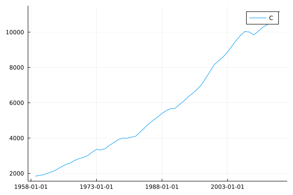

```julia
plot(ts_CONS_USA[:C])
```

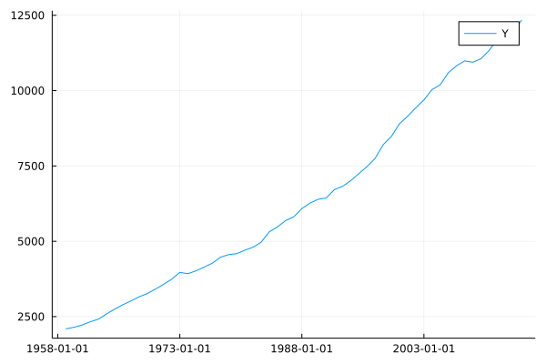

```julia
plot(ts_CONS_USA[:Y])
```

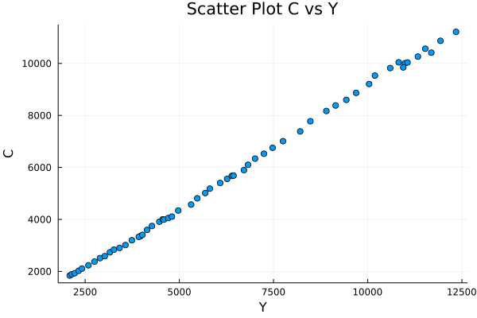

```julia
scatter(CONS_USA.Y, CONS_USA.C, title = "Scatter Plot C vs Y", ylabel = "C", xlabel = "Y",legend = false)
```

## Regresiones por MCO

Se estimará por MCO el siguiente modelo de regresión lineal:

$$C_{t} = \beta_0 + \beta_1 Y_{t} + e_{t}$$

**R**

Comando `lm` de *R stats* (https://rdrr.io/r/stats/lm.html).

```r
KEYNES_model <- lm (formula = C ~ Y, data = ts_CONS_USA)
summary(KEYNES_model)
```

```
Call:
lm(formula = C ~ Y, data = ts_CONS_USA)

Residuals:
     Min       1Q   Median       3Q      Max
-252.922  -52.961   -6.074   55.160  263.545

Coefficients:
              Estimate Std. Error t value Pr(>|t|)
(Intercept) -2.455e+02  2.828e+01  -8.681 6.87e-12 ***
Y            9.336e-01  3.967e-03 235.338  < 2e-16 ***
---
Signif. codes:  0 '***' 0.001 '**' 0.01 '*' 0.05 '.' 0.1 ' ' 1

Residual standard error: 92.95 on 55 degrees of freedom
Multiple R-squared:  0.999, Adjusted R-squared:  0.999
F-statistic: 5.538e+04 on 1 and 55 DF,  p-value: < 2.2e-16
```

**Python**

Comando `smf.ols` de la librería `statsmodels` (https://www.statsmodels.org/).

```python
model = smf.ols(formula = "C ~ Y", data = ts_CONS_USA)
KEYNES_model = model.fit()
print(KEYNES_model.summary())
```

```
                            OLS Regression Results
==============================================================================
Dep. Variable:                      C   R-squared:                       0.999
Model:                            OLS   Adj. R-squared:                  0.999
Method:                 Least Squares   F-statistic:                 5.538e+04
Date:                lun, 19 sep 2022   Prob (F-statistic):           2.72e-84
Time:                        09:18:48   Log-Likelihood:                -338.19
No. Observations:                  57   AIC:                             680.4
Df Residuals:                      55   BIC:                             684.5
Df Model:                           1
Covariance Type:            nonrobust
==============================================================================
                 coef    std err          t      P>|t|      [0.025      0.975]
------------------------------------------------------------------------------
Intercept   -245.5102     28.282     -8.681      0.000    -302.189    -188.832
Y              0.9336      0.004    235.338      0.000       0.926       0.942
==============================================================================
Omnibus:                        2.088   Durbin-Watson:                   0.691
Prob(Omnibus):                  0.352   Jarque-Bera (JB):                1.264
Skew:                           0.240   Prob(JB):                        0.532
Kurtosis:                       3.549   Cond. No.                     1.64e+04
==============================================================================

Notes:
[1] Standard Errors assume that the covariance matrix of the errors is correctly specified.
[2] The condition number is large, 1.64e+04. This might indicate that there are
strong multicollinearity or other numerical problems.
```

**Julia**

Comando `lm` de la librería `GLM` (https://juliastats.org/GLM.jl/) de JuliaStats (https://juliastats.org/), el *statsverse* de Julia.

```julia
KEYNES_model = lm(@formula(C ~ Y), ts_CONS_USA)
```

```
StatsModels.TableRegressionModel{LinearModel{GLM.LmResp{Vector{Float64}}, GLM.DensePredChol{Float64, CholeskyPivoted{Float64, Matrix{Float64}, Vector{Int64}}}}, Matrix{Float64}}

C ~ 1 + Y

Coefficients:
─────────────────────────────────────────────────────────────────────────────────
                   Coef.   Std. Error       t  Pr(>|t|)    Lower 95%    Upper 95%
─────────────────────────────────────────────────────────────────────────────────
(Intercept)  -245.51      28.282        -8.68    <1e-11  -302.189     -188.832
Y               0.933592   0.00396702  235.34    <1e-83     0.925642     0.941542
─────────────────────────────────────────────────────────────────────────────────
```

```julia
regtable(KEYNES_model)
```

```
-------------------------
                   C
              -----------
                      (1)
-------------------------
(Intercept)   -245.510***
                 (28.282)
Y                0.934***
                  (0.004)
-------------------------
Estimator             OLS
-------------------------
N                      57
R2                  0.999
-------------------------
```

Comando `fit` de la librería `Econometrics` (https://juliapackages.com/p/econometrics).

```julia
KEYNES_model_2 = fit(EconometricModel, @formula(C ~ Y), ts_CONS_USA)
```

```
Continuous Response Model
Number of observations: 57
Null Loglikelihood: -535.29
Loglikelihood: -338.21
R-squared: 0.9990
LR Test: 394.16 ∼ χ²(1) ⟹  Pr > χ² = 0.0000
Formula: C ~ 1 + Y
Variance Covariance Estimator: OIM
────────────────────────────────────────────────────────────────────────────────────
                   PE           SE       t-value  Pr > |t|        2.50%       97.50%
────────────────────────────────────────────────────────────────────────────────────
(Intercept)  -245.51      28.282        -8.68081    <1e-11  -302.189     -188.832
Y               0.933592   0.00396702  235.338      <1e-83     0.925642     0.941542
────────────────────────────────────────────────────────────────────────────────────
```

## Anexos

### Anexo 1: Clase `tsibble` y librería `fpp3` (específicas para el análisis de series temporales)

La clase `tsibble` proporciona una infraestructura de datos para ‘ordenar’ las series temporales y además dispone de herramientas de ‘manipulación’. Se pueden encontrar los detalles en la página web https://tsibble.tidyverts.org/index.html.

La ‘macro-librería’ `fpp3` contiene varias librerías específicas (https://tidyverts.org/) y otras generales, como `tidyverse` (https://www.tidyverse.org/) y `lubridate` (https://lubridate.tidyverse.org/). Toda la información se encuentra en: https://github.com/robjhyndman/fpp3package. El libro de texto que acompaña a esta librería es el siguiente: https://otexts.com/fpp3/.

Existen otras librerías específicas para series temporales, entre las que cabe destacar `TSstudio` (https://ramikrispin.github.io/TSstudio/) , `timetk` (https://business-science.github.io/timetk/) y `tsbox` (https://www.tsbox.help/).

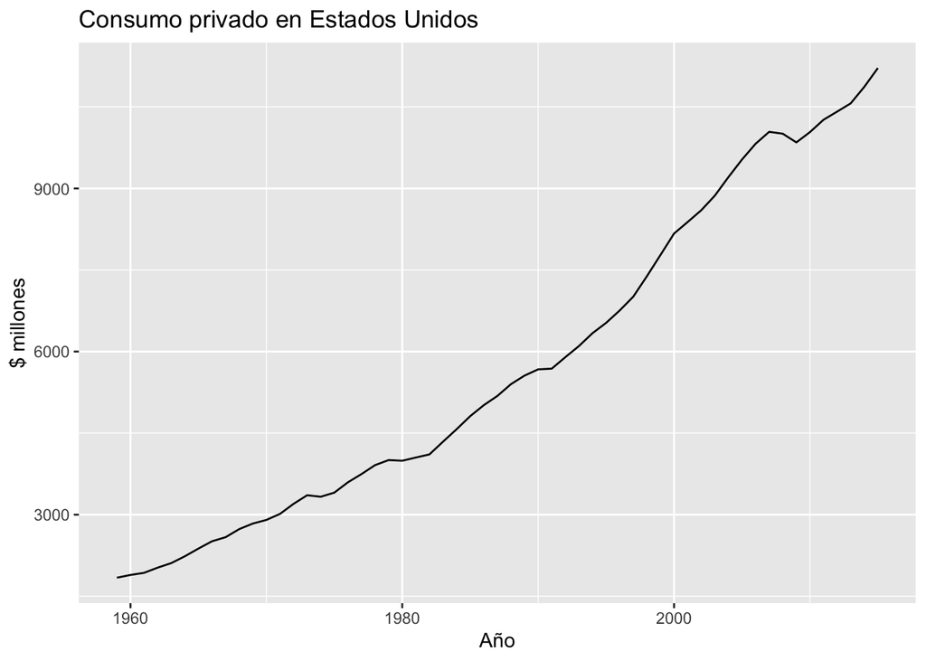

```r
library(fpp3)
# Creación del objeto tsibble
tsbl_CONS_USA <-  CONS_USA[,2:3] %>%
  mutate(Year = 1959:2015) %>%
  as_tsibble(index = Year)
# Gráficas individuales
tsbl_CONS_USA %>% autoplot(C) +
  ggtitle("Consumo privado en Estados Unidos") +
  ylab("$ millones") + xlab("Año")
```

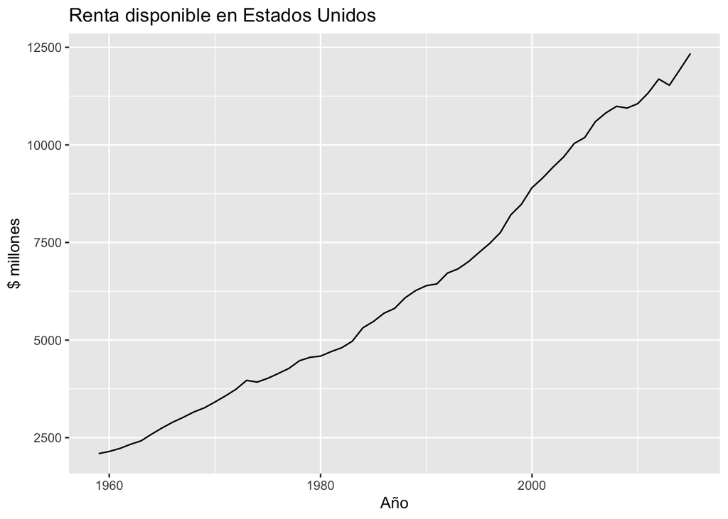

```r
tsbl_CONS_USA %>% autoplot(Y) +
  ggtitle("Renta disponible en Estados Unidos") +
  ylab("$ millones") + xlab("Año")
```

```r
# Estimación de la función Keynesiana de consumo para Estados Unidos (1959-2015)
tsbl_CONS_USA %>%
  model(tslm = TSLM(C ~ Y)) %>%
  report()
```

```
Series: C
Model: TSLM

Residuals:
     Min       1Q   Median       3Q      Max
-252.922  -52.961   -6.074   55.160  263.545

Coefficients:
              Estimate Std. Error t value Pr(>|t|)
(Intercept) -2.455e+02  2.828e+01  -8.681 6.87e-12 ***
Y            9.336e-01  3.967e-03 235.338  < 2e-16 ***
---
Signif. codes:  0 '***' 0.001 '**' 0.01 '*' 0.05 '.' 0.1 ' ' 1

Residual standard error: 92.95 on 55 degrees of freedom
Multiple R-squared: 0.999,  Adjusted R-squared: 0.999
F-statistic: 5.538e+04 on 1 and 55 DF, p-value: < 2.22e-16
```